# Project: Investigate a Dataset ford go bike trip

- Introduction
- Data Wrangling
- Exploratory Data Analysis
- Explantory Data Analysis
- Conclusions

## Introduction

the dataset about go ford bike trip it contions the duration of each trip the start time the end time the birth year of users and if they customers or subscriber we are gonna load the data make insights and trying to solve this three quatsions

When are most trips taken in terms of time of day, day of the week, or month of the year?

How long does the average trip take?

Does the avrage trip depend on if a user is a subscriber or customer?

### Explantory Data Anaylsis

### Research Question 1: When are most trips taken in terms of time of day, day of the week, or month of the year?

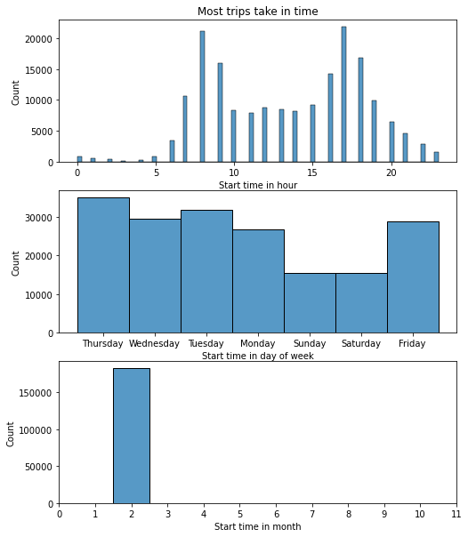

### Research Question 2: How long does the average trip take?

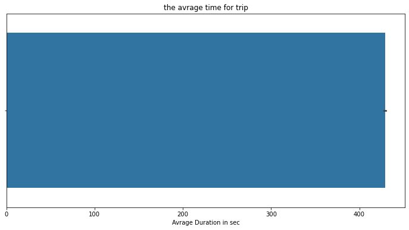

### Research Question 3 :Does the avrage time depend on if a user is a subscriber or customer?

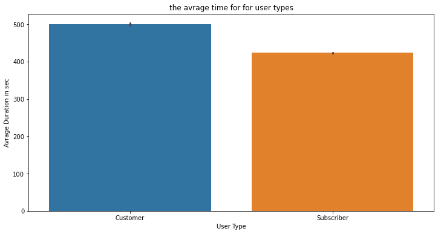

## Conclusions

now we have three important insights about the data ,first we know excatly which time users most take in by hour,day and month second the avrage time for each trip and third is the avrage time for customer and subscriber